# Application of ERGM Count in Network Representation of Football Matches

Imaduddin Haetami

09/02/2017

# Specification of ERGM Count

- In ERGM Count, an edge can have any value of natural numbers including zero, such that $y_{ij} \in \mathbb{N}_0$.
- The ERGM Count of $\mathbf{Y}$ has Probability Mass Function (PMF) of:
  $$Pr_{\mathbf{\theta};h,\eta,g}(\mathbf{Y}=\mathbf{y})=\frac{h(\mathbf{y})\exp(\eta(\mathbf{\theta})\cdot g(\mathbf{y}))}{k_{h,\eta,g}(\mathbf{\theta})}$$
- Which the denominator is a normalization constant defined as:
  $$k_{h,\eta,g}(\mathbf{\theta}) = \sum_{\mathbf{y} \in \mathcal{Y}}h(\mathbf{y})\exp(\eta(\mathbf{\theta})\cdot g(\mathbf{y}))$$

# Reference Measure and Baseline Distribution

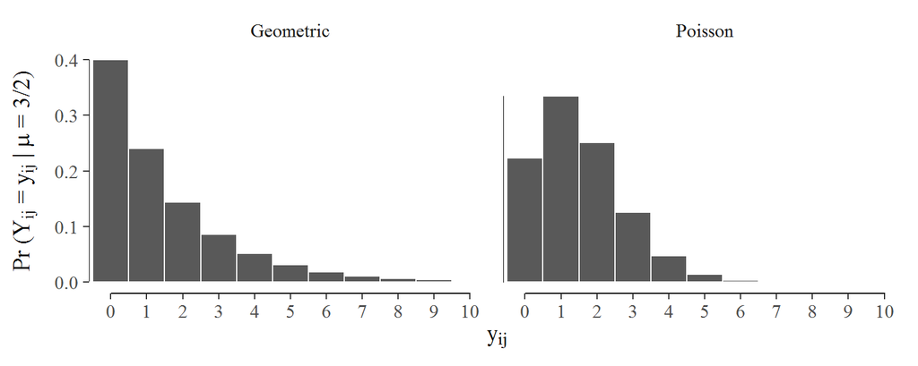

Geometric and Poisson Distribution with Mean = 1.5

# Reference Measure and Baseline Distribution (Geometric)

- Using sufficient statistics, **sum** : $g(\mathbf{y}) = \sum_{(i,j) \in \mathbb{Y}} y_{ij}$
- Geometric reference measure: $h(\mathbf{y}) = 1$
- The model has PMF:
  $$Pr(\mathbf{Y}=\mathbf{y}|\theta) \propto \exp\left(\theta \sum_{(i,j) \in \mathbb{Y}} y_{ij}\right) = \prod_{(i,j) \in \mathbb{Y}} (\exp(\theta))^{y_{ij}}$$
- This can be identified as **edge-wise distribution** $Y_{ij}\stackrel{\text{iid}}{\sim}\text{geometric}(p =1-\exp(\theta))$ where $\theta < 0$

|  | parameter | Estimate | Std. Error | p-value |
| --- | --- | --- | --- | --- |
| I |  |  |  |  |
| 1 | sum | -0.5570 | 0.0280 | 0.0000 |
| II |  |  |  |  |
| 2 | sum | -0.5311 | 0.0275 | 0.0000 |
| III |  |  |  |  |
| 3 | sum | -0.5723 | 0.0290 | 0.0000 |
| IV |  |  |  |  |
| 4 | sum | -0.5794 | 0.0300 | 0.0000 |
| V |  |  |  |  |
| 5 | sum | -0.5700 | 0.0292 | 0.0000 |
| VI |  |  |  |  |
| 6 | sum | -0.5388 | 0.0273 | 0.0000 |

# Reference Measure and Baseline Distribution (Poisson)

- Using sufficient statistics, **sum** : $g(\mathbf{y}) = \sum_{(i,j) \in \mathbb{Y}} y_{ij}$
- Poisson reference measure: $h(\mathbf{y}) = \prod_{(i,j) \in \mathbb{Y}}(y_{ij}!)^{-1}$
- The model has PMF:
  $$Pr(\mathbf{Y}=\mathbf{y}|\theta) \propto \frac{\exp\left(\theta \sum_{(i,j) \in \mathbb{Y}} y_{ij}\right)}{\prod_{(i,j) \in \mathbb{Y}}y_{ij}!} = \prod_{(i,j) \in \mathbb{Y}} \frac{(\exp(\theta))^{y_{ij}}}{y_{ij}!}$$
- This can be identified as **edge-wise distribution** $Y_{ij}\stackrel{\text{iid}}{\sim}\text{poisson}(\lambda =\exp(\theta))$ where $\theta \in \mathbb{R}$.

|  | parameter | Estimate | Std. Error | p-value |
| --- | --- | --- | --- | --- |
| I |  |  |  |  |
| 1 | sum | 0.2920 | 0.0443 | 0.0000 |
| II |  |  |  |  |
| 2 | sum | 0.3566 | 0.0429 | 0.0000 |
| III |  |  |  |  |
| 3 | sum | 0.2578 | 0.0459 | 0.0000 |
| IV |  |  |  |  |
| 4 | sum | 0.2393 | 0.0444 | 0.0000 |
| V |  |  |  |  |
| 5 | sum | 0.2625 | 0.0448 | 0.0000 |
| VI |  |  |  |  |
| 6 | sum | 0.3344 | 0.0435 | 0.0000 |

# Poisson Reference Model

we will focus on ERGM Count without complex constraints: $\mathcal{Y} \in \mathcal{N}_0^{\mathcal{Y}}$ and $h(\mathbf{y}) = \prod_{(i,j) \in \mathbb{Y}}(y_{ij}!)^{-1}$.

# Exogenous Covariates

$$g_k(\mathbf{y})= \sum_{(i,j) \in \mathbb{Y}} y_{ij}x_{ijk}$$

- Let the model sufficient statistics only be exogenous covariate and **sum**
- the PMF will reduce to:
  $$\begin{eqnarray}
  Pr(\mathbf{Y}=\mathbf{y}|\theta) &\propto \frac{\exp\left(\theta_1 \sum_{(i,j) \in \mathbb{Y}} y_{ij} + \theta_k \sum_{(i,j) \in \mathbb{Y}} y_{ij}x_{ijk} \right)}{\prod_{(i,j) \in \mathbb{Y}}y_{ij}!}\\
  &= \prod_{(i,j) \in \mathbb{Y}} \frac{(\exp(\theta_1+\theta_k x_{ijk}))^{y_{ij}}}{y_{ij}!}
  \end{eqnarray}$$
- This can be recognised as an **edge-wise distribution** $Y_{ij}\stackrel{\text{iid}}{\sim}\text{poisson}(\lambda =\exp(\theta_1 + \theta_k x_{ijk}))$

# Implementation of Exogenous Covariates

- **nodeocov** : the attribute of the actor where the edge originate, $x_{i}$.
- **nodeicov** : the attribute of receiving actor, $x_j$.
- **edgecov** : which represent the external edge attribute, $x_{ij}$.

# **nodeocov**

|  | parameter | Estimate | Std. Error | p-value |
| --- | --- | --- | --- | --- |
| I |  |  |  |  |
| 1 | nodeocov.sum..market_value | 0.0517 | 0.0048 | 0.0000 |
| II |  |  |  |  |
| 2 | nodeocov.sum..market_value | 0.0540 | 0.0048 | 0.0000 |
| III |  |  |  |  |
| 3 | nodeocov.sum..market_value | 0.0511 | 0.0060 | 0.0000 |
| IV |  |  |  |  |
| 4 | nodeocov.sum..market_value | 0.0462 | 0.0060 | 0.0000 |
| V |  |  |  |  |
| 5 | nodeocov.sum..market_value | 0.0405 | 0.0066 | 0.0000 |
| VI |  |  |  |  |
| 6 | nodeocov.sum..market_value | 0.0557 | 0.0060 | 0.0000 |

# **nodeicov**

|  | parameter | Estimate | Std. Error | p-value |
| --- | --- | --- | --- | --- |
| I |  |  |  |  |
| 1 | nodeicov.sum..market_value | 0.0219 | 0.0060 | 0.0003 |
| II |  |  |  |  |
| 2 | nodeicov.sum..market_value | 0.0225 | 0.0059 | 0.0002 |
| III |  |  |  |  |
| 3 | nodeicov.sum..market_value | 0.0174 | 0.0072 | 0.0158 |
| IV |  |  |  |  |
| 4 | nodeicov.sum..market_value | 0.0181 | 0.0071 | 0.0106 |
| V |  |  |  |  |
| 5 | nodeicov.sum..market_value | 0.0256 | 0.0070 | 0.0003 |
| VI |  |  |  |  |
| 6 | nodeicov.sum..market_value | 0.0325 | 0.0068 | 0.0000 |

# **edgecov**

|  | parameter | Estimate | Std. Error | p-value |
| --- | --- | --- | --- | --- |
| I |  |  |  |  |
| 1 | edgecov.home_mat.sum | 0.4390 | 0.0583 | 0.0000 |
| II |  |  |  |  |
| 2 | edgecov.home_mat.sum | 0.4682 | 0.0568 | 0.0000 |
| III |  |  |  |  |
| 3 | edgecov.home_mat.sum | 0.3847 | 0.0608 | 0.0000 |
| IV |  |  |  |  |
| 4 | edgecov.home_mat.sum | 0.3926 | 0.0601 | 0.0000 |
| V |  |  |  |  |
| 5 | edgecov.home_mat.sum | 0.3500 | 0.0621 | 0.0000 |
| VI |  |  |  |  |
| 6 | edgecov.home_mat.sum | 0.4444 | 0.0567 | 0.0000 |

# combination

|  | parameter | Estimate | Std. Error | p-value |
| --- | --- | --- | --- | --- |
| I |  |  |  |  |
| 1 | sum | -0.1758 | 0.1147 | 0.1263 |
| 2 | edgecov.home_mat.sum | 0.3103 | 0.0896 | 0.0006 |
| 3 | nodeocov.sum..market_value | 0.0648 | 0.0084 | 0.0000 |
| 4 | nodeicov.sum..market_value | -0.0240 | 0.0111 | 0.0310 |
| II |  |  |  |  |
| 5 | sum | 0.1360 | 0.1115 | 0.2235 |
| 6 | edgecov.home_mat.sum | 0.2437 | 0.0885 | 0.0062 |
| 7 | nodeocov.sum..market_value | 0.0527 | 0.0085 | 0.0000 |
| 8 | nodeicov.sum..market_value | -0.0456 | 0.0111 | 0.0001 |
| III |  |  |  |  |
| 9 | sum | -0.0609 | 0.1183 | 0.6072 |
| 10 | edgecov.home_mat.sum | 0.2804 | 0.0919 | 0.0024 |
| 11 | nodeocov.sum..market_value | 0.0627 | 0.0106 | 0.0000 |
| 12 | nodeicov.sum..market_value | -0.0393 | 0.0129 | 0.0025 |
| IV |  |  |  |  |
| 13 | sum | -0.0876 | 0.1219 | 0.4730 |
| 14 | edgecov.home_mat.sum | 0.3237 | 0.0938 | 0.0006 |
| 15 | nodeocov.sum..market_value | 0.0531 | 0.0109 | 0.0000 |
| 16 | nodeicov.sum..market_value | -0.0307 | 0.0132 | 0.0202 |
| V |  |  |  |  |
| 17 | sum | 0.1579 | 0.1220 | 0.1964 |
| 18 | edgecov.home_mat.sum | 0.1816 | 0.0893 | 0.0427 |
| 19 | nodeocov.sum..market_value | 0.0263 | 0.0120 | 0.0293 |
| 20 | nodeicov.sum..market_value | -0.0265 | 0.0138 | 0.0559 |
| VI |  |  |  |  |
| 21 | sum | 0.1210 | 0.1198 | 0.3130 |
| 22 | edgecov.home_mat.sum | 0.2447 | 0.0870 | 0.0052 |
| 23 | nodeocov.sum..market_value | 0.0487 | 0.0114 | 0.0000 |
| 24 | nodeicov.sum..market_value | -0.0371 | 0.0138 | 0.0073 |

# Zero Modification

The idea behind zero modification is to move away from the baseline distribution with new PMF that has more accurate representation of its $Pr(Y_{ij}=0)$

**nonzero**: $g(\mathbf{y}) = \sum_{(i,j) \in \mathbb{Y}} \mathbb{I}(y_{ij} > 0)$

- Let the model sufficient statistics only be **nonzero** and **sum**
- Then the PMF will reduce to:
  $$\begin{eqnarray}
  Pr(\mathbf{Y}=\mathbf{y}|\theta_1,\theta_2) &\propto \frac{\exp\left(\theta_1 \sum_{(i,j) \in \mathbb{Y}} y_{ij} + \theta_2 \sum_{(i,j) \in \mathbb{Y}} \mathbb{I}(y_{ij} > 0)\right)}{\prod_{(i,j) \in \mathbb{Y}}y_{ij}!}\\
  &=\prod_{(i,j) \in \mathbb{Y}} \frac{\exp \left(\theta_1 y_{ij} + \theta_2 \mathbb{I}(y_{ij} > 0)\right)}{y_{ij}!}
  \end{eqnarray}$$
- This can be recognised as independent edge-wise Zero Modified Poisson

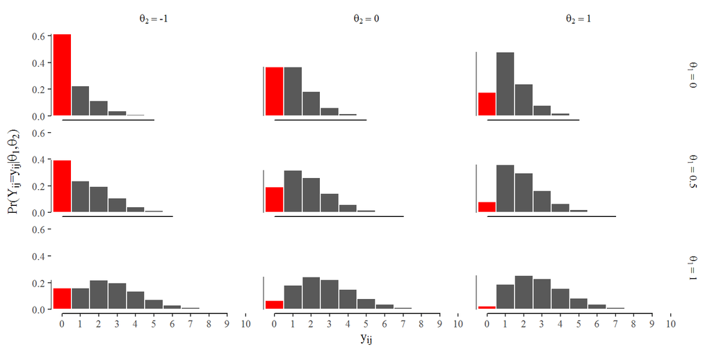

Zero Modified Poisson

|  | parameter | Estimate | Std. Error | p-value |
| --- | --- | --- | --- | --- |
| I |  |  |  |  |
| 1 | sum | 0.4163 | 0.0582 | 0.0000 |
| 2 | nonzero | -0.4703 | 0.1567 | 0.0029 |
| II |  |  |  |  |
| 3 | sum | 0.5020 | 0.0562 | 0.0000 |
| 4 | nonzero | -0.5935 | 0.1601 | 0.0002 |
| III |  |  |  |  |
| 5 | sum | 0.2831 | 0.0621 | 0.0000 |
| 6 | nonzero | -0.0989 | 0.1590 | 0.5343 |
| IV |  |  |  |  |
| 7 | sum | 0.3080 | 0.0620 | 0.0000 |
| 8 | nonzero | -0.2452 | 0.1575 | 0.1204 |
| V |  |  |  |  |
| 9 | sum | 0.3331 | 0.0599 | 0.0000 |
| 10 | nonzero | -0.2640 | 0.1570 | 0.0935 |
| VI |  |  |  |  |
| 11 | sum | 0.3823 | 0.0583 | 0.0000 |
| 12 | nonzero | -0.1891 | 0.1578 | 0.2315 |

# Dispersion Modelling

Poisson distribution has only 1 parameter that affect the distribution. This parameter found to affect the mean and the spread of the distribution. For one particular value of mean, there is only one particular spread poisson can attain. In other words, the spread is fixed and not adjustable.

**CMP**: $g(\mathbf{y}) = \sum_{(i,j) \in \mathbb{Y}} \log(y_{ij}!)$

- Let the model sufficient statistics only be **CMP** and **sum**
- Then the PMF will reduce to:
  $$\begin{eqnarray}
  Pr(\mathbf{Y}=\mathbf{y}|\theta_1,\theta_2) &\propto \frac{\exp\left(\theta_1 \sum_{(i,j) \in \mathbb{Y}} y_{ij} + \theta_2 \sum_{(i,j) \in \mathbb{Y}} \log(y_{ij}!)\right)}{\prod_{(i,j) \in \mathbb{Y}}y_{ij}!}\\
  &\propto \prod_{(i,j) \in \mathbb{Y}} (\exp(\theta_1))^{y_{ij}} (y_{ij}!)^{\theta_2-1}
  \end{eqnarray}$$
- Hence the model reduced to edge-wise *Conway-Maxwell-Poisson* **CMP** distribution $Y_{ij}\stackrel{\text{iid}}{\sim}\text{CMP}(\lambda =\exp(\theta_1),\nu = 1-\theta_2)$ where $\theta_2 \le 1$.

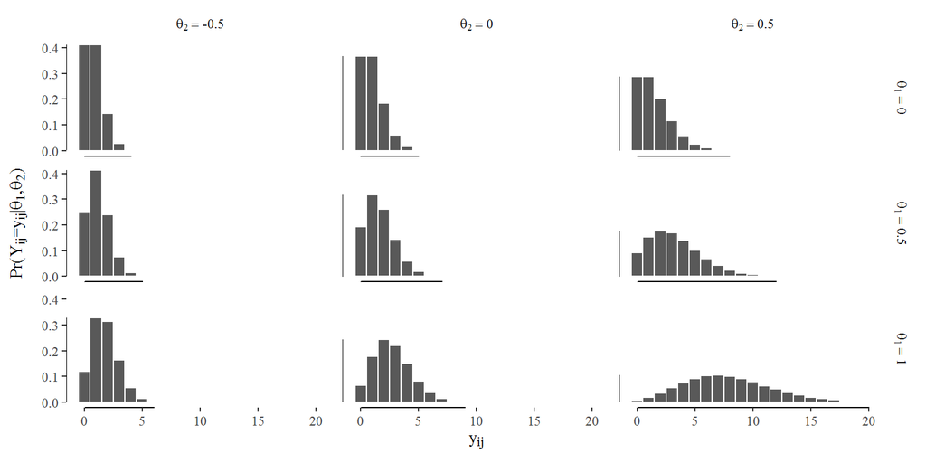

Conway-Maxwell-Poisson Distribution

|  | parameter | Estimate | Std. Error | p-value |
| --- | --- | --- | --- | --- |
| I |  |  |  |  |
| 1 | sum | 0.0248 | 0.0913 | 0.7863 |
| 2 | CMP | 0.3537 | 0.1045 | 0.0008 |
| II |  |  |  |  |
| 3 | sum | 0.0741 | 0.0937 | 0.4295 |
| 4 | CMP | 0.3584 | 0.1028 | 0.0005 |
| III |  |  |  |  |
| 5 | sum | 0.2297 | 0.0988 | 0.0206 |
| 6 | CMP | 0.0402 | 0.1254 | 0.7485 |
| IV |  |  |  |  |
| 7 | sum | 0.0685 | 0.0968 | 0.4798 |
| 8 | CMP | 0.2390 | 0.1180 | 0.0435 |
| V |  |  |  |  |
| 9 | sum | 0.1278 | 0.0957 | 0.1822 |
| 10 | CMP | 0.1833 | 0.1160 | 0.1150 |
| VI |  |  |  |  |
| 11 | sum | 0.2407 | 0.0970 | 0.0135 |
| 12 | CMP | 0.1255 | 0.1122 | 0.2640 |

# Mutuality

The previous sections discussed the various models that has independent edge-wise assumption. However, fitting network data to independent edge-wise model will undermine the inherent relational characteristic of network properties.

Addition of mutuality will reduce to model with independent pair-wise distribution

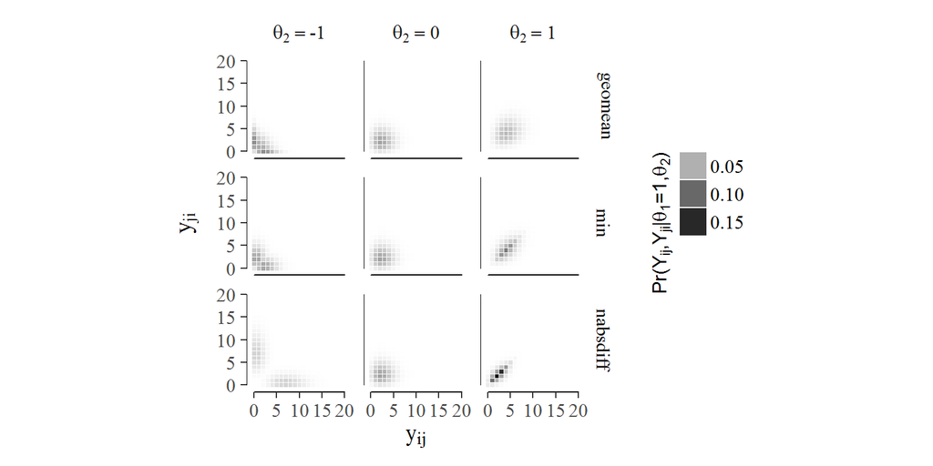

# Minimum

**mutual(min)**: $g(\mathbf{y}) = \sum_{(i,j)\in\mathbb{Y},i<j} \min(y_{ij},y_{ji})$

- Let the model sufficient statistics only be **mutual(min)** and **sum**
- Then the PMF will reduce to:
  $$\begin{eqnarray}
  Pr(\mathbf{Y}=\mathbf{y}|\theta_1,\theta_2) &\propto \frac{\exp\left(\theta_1 \sum_{(i,j) \in \mathbb{Y}} y_{ij} + \theta_{2}\sum_{(i,j)\in\mathbb{Y},i<j} \min(y_{ij},y_{ji})\right)}{\prod_{(i,j) \in \mathbb{Y}}y_{ij}!}\\
  &= \frac{\exp\left(\theta_1 \sum_{(i,j) \in \mathbb{Y},i<j} (y_{ij}+y_{ji}) + \theta_{2}\sum_{(i,j)\in\mathbb{Y},i<j} \min(y_{ij},y_{ji})\right)}{\prod_{(i,j) \in \mathbb{Y},i<j}y_{ij}!y_{ji}!}\\
  &= \prod_{(i,j) \in \mathbb{Y},i<j} \frac{\exp(\theta_1(y_{ij}+y_{ji})+\theta_2 \min(y_{ij},y_{ji}))}{y_{ij}!y_{ji}!}
  \end{eqnarray}$$
- the joint distribution of $(Y_{ij},Y_{ji})$ has PMF:
  $$\begin{eqnarray}
  P(Y_{ij}=y_{ij},Y_{ji}=y_{ji}|\theta_1,\theta_2) \propto \frac{\exp(\theta_1(y_{ij}+y_{ji})+\theta_2 \min(y_{ij},y_{ji}))}{y_{ij}!y_{ji}!}
  \end{eqnarray}$$

|  | parameter | Estimate | Std. Error | p-value |
| --- | --- | --- | --- | --- |
| I |  |  |  |  |
| 1 | sum | 0.4082 | 0.0660 | 0.0000 |
| 2 | mutual.min | -0.3268 | 0.1458 | 0.0256 |
| II |  |  |  |  |
| 3 | sum | 0.5714 | 0.0613 | 0.0000 |
| 4 | mutual.min | -0.6245 | 0.1353 | 0.0000 |
| III |  |  |  |  |
| 5 | sum | 0.2612 | 0.0718 | 0.0003 |
| 6 | mutual.min | -0.0122 | 0.1511 | 0.9356 |
| IV |  |  |  |  |
| 7 | sum | 0.3600 | 0.0660 | 0.0000 |
| 8 | mutual.min | -0.3425 | 0.1448 | 0.0186 |
| V |  |  |  |  |
| 9 | sum | 0.2884 | 0.0713 | 0.0001 |
| 10 | mutual.min | -0.0745 | 0.1502 | 0.6203 |
| VI |  |  |  |  |
| 11 | sum | 0.3765 | 0.0676 | 0.0000 |
| 12 | mutual.min | -0.1103 | 0.1422 | 0.4387 |

# Negative Absolute Difference

**mutual(nabsdiff)**: $g(\mathbf{y}) = \sum_{(i,j)\in\mathbb{Y},i<j} -|y_{ij} - y_{ji}|$

- Let the model sufficient statistics only be **mutual(nabsdiff)** and **sum**
- Then the PMF will reduce to:
  $$Pr(Y_{ij}=y_{ij},Y_{ji}=y_{ji}| \theta_1,\theta_2) \propto \frac{\exp(\theta_1 (y_{ij}+y_{ji}) - \theta_2 |y_{ij}-y_{ji}|)}{y_{ij}!y_{ji}!}$$

|  | parameter | Estimate | Std. Error | p-value |
| --- | --- | --- | --- | --- |
| I |  |  |  |  |
| 1 | sum | 0.2448 | 0.0503 | 0.0000 |
| 2 | mutual.nabsdiff | -0.1634 | 0.0729 | 0.0256 |
| II |  |  |  |  |
| 3 | sum | 0.2591 | 0.0509 | 0.0000 |
| 4 | mutual.nabsdiff | -0.3122 | 0.0677 | 0.0000 |
| III |  |  |  |  |
| 5 | sum | 0.2551 | 0.0500 | 0.0000 |
| 6 | mutual.nabsdiff | -0.0061 | 0.0755 | 0.9356 |
| IV |  |  |  |  |
| 7 | sum | 0.1888 | 0.0521 | 0.0003 |
| 8 | mutual.nabsdiff | -0.1712 | 0.0724 | 0.0186 |
| V |  |  |  |  |
| 9 | sum | 0.2511 | 0.0498 | 0.0000 |
| 10 | mutual.nabsdiff | -0.0372 | 0.0751 | 0.6203 |
| VI |  |  |  |  |
| 11 | sum | 0.3214 | 0.0474 | 0.0000 |
| 12 | mutual.nabsdiff | -0.0551 | 0.0711 | 0.4387 |

# Geometric Mean

|  | parameter | Estimate | Std. Error | p-value |
| --- | --- | --- | --- | --- |
| I |  |  |  |  |
| 1 | sum | 0.4200 | 0.0758 | 0.0000 |
| 2 | mutual.geom.mean | -0.2578 | 0.1268 | 0.0428 |
| II |  |  |  |  |
| 3 | sum | 0.6313 | 0.0669 | 0.0000 |
| 4 | mutual.geom.mean | -0.5627 | 0.1079 | 0.0000 |
| III |  |  |  |  |
| 5 | sum | 0.2690 | 0.0837 | 0.0014 |
| 6 | mutual.geom.mean | -0.0238 | 0.1416 | 0.8664 |
| IV |  |  |  |  |
| 7 | sum | 0.3751 | 0.0764 | 0.0000 |
| 8 | mutual.geom.mean | -0.2770 | 0.1314 | 0.0356 |
| V |  |  |  |  |
| 9 | sum | 0.2729 | 0.0830 | 0.0011 |
| 10 | mutual.geom.mean | -0.0248 | 0.1410 | 0.8603 |
| VI |  |  |  |  |
| 11 | sum | 0.4476 | 0.0753 | 0.0000 |
| 12 | mutual.geom.mean | -0.2219 | 0.1259 | 0.0787 |

# Predictive Modelling

|  | model_name | data_1 | data_2 | data_3 | data_4 | data_5 | data_6 |
| --- | --- | --- | --- | --- | --- | --- | --- |
| 1 | sum | -37.2233 | -58.6550 | -27.7248 | -23.1036 | -28.6160 | -51.4861 |
| 2 | sum + nonzero | -43.8867 | -70.3393 | -25.9417 | -23.3522 | -29.6838 | -51.5647 |
| 3 | sum + CMP | -45.2962 | -68.0866 | -25.8699 | -24.8494 | -29.2238 | -50.6053 |
| 4 | nodeocov | -87.5170 | -96.6723 | -60.0592 | -46.3396 | -32.4321 | -69.2334 |
| 5 | nodeicov | -9.5350 | -10.5979 | -3.6897 | -4.1336 | -10.3984 | -18.6609 |
| 6 | edgecov | -46.3774 | -55.6937 | -34.1714 | -35.5902 | -27.9407 | -48.9472 |
| 7 | edgecov + nodeocov + nodeicov | -100.9382 | -116.4051 | -77.3241 | -61.8690 | -36.1242 | -78.8046 |
| 8 | sum + edgecov + nodeocov + nodeicov | -102.0293 | -116.2660 | -75.6059 | -60.8011 | -36.1133 | -78.1467 |
| 9 | nonzero + edgecov + nodeocov + nodeicov | -103.4881 | -117.1525 | -74.2900 | -60.1187 | -34.1979 | -77.1224 |
| 10 | CMP + edgecov + nodeocov + nodeicov | -98.0150 | -117.1650 | -78.2457 | -60.3249 | -37.2516 | -77.2820 |
| 11 | nonzero + CMP + edgecov + nodeocov + nodeicov | -100.9587 | -116.6159 | -76.4241 | -58.9126 | -35.0366 | -74.5290 |
| 12 | sum + mutual | -40.2675 | -77.5878 | -26.0595 | -26.4320 | -27.2528 | -50.5447 |
| 13 | sum + mutual | -40.2675 | -77.5878 | -26.0595 | -26.4320 | -27.2527 | -50.5447 |
| 14 | sum + mutual | -39.0681 | -78.6989 | -25.6381 | -25.0202 | -26.9793 | -52.3807 |
| 15 | mutual + edgecov + nodeocov + nodeicov | -99.8099 | -120.4930 | -80.9673 | -60.0204 | -34.6082 | -77.2474 |
| 16 | nonzero + mutual + edgecov + nodeocov + nodeicov | -101.5813 | -118.4253 | -79.3224 | -57.8536 | -32.7930 | -75.2288 |
| 17 | CMP + mutual + edgecov + nodeocov + nodeicov | -97.4651 | -118.9933 | -78.7503 | -58.3122 | -35.8765 | -76.0570 |
| 18 | CMP + mutual + edgecov + nodeocov + nodeicov | -97.4651 | -118.9933 | -78.7503 | -58.3122 | -35.8765 | -76.0570 |
| 19 | sum + transitiveweights | -40.3161 | -59.7166 | -25.8094 | -22.0933 | -27.1899 | -49.0963 |